# Computer Assignment 3 - Naive Bayes Classification

## Artificial Intelligence Course, University of Tehran, Spring 2021

## 0. Before We Begin

The following libraries were used in our implementation of Naive Bayes:

```python
from __future__ import unicode_literals
from sklearn.metrics import classification_report
from IPython.display import display
from hazm import *
import pandas as pd
import numpy as np
import matplotlib
import codecs, time
```

```python
train_df = pd.read_csv('./books_dataset/books_train.csv')
test_df = pd.read_csv('./books_dataset/books_test.csv')
```

```python
display(train_df)
```

|  | title | description | categories |
| --- | --- | --- | --- |
| 0 | ساختار نظریه‌های جامعه‌شناسی ایران | «ساختار نظریه‌های جامعه‌شناسی ایران» نوشته ابو... | جامعه‌شناسی |
| 1 | جامعه و فرهنگ کانادا | «جامعه و فرهنگ کانادا» از مجموعه کتاب‌های «جام... | جامعه‌شناسی |
| 2 | پرسش از موعود | پرسش‌های مختلفی درباره زندگی و شخصیت امام مهدی... | کلیات اسلام |
| 3 | موج، دریا | «موج دریا» به قلم مهری ماهوتی (-۱۳۴۰) و تصویرگ... | داستان کودک و نوجوانان |
| 4 | پرسش از غرب | «پرسش از غرب» به قلم دکتر اسماعیل شفیعی سروستا... | جامعه‌شناسی |
| ... | ... | ... | ... |
| 2545 | قضاوت‌های امیرمؤمنان حضرت علی علیه‌السلام | آنچه به عنوان قضاوت‌های امیرمؤمنان حضرت علی عل... | کلیات اسلام |
| 2546 | کراماتی از مهدی موعود(عج) | زینب محمودی پژوهشگر دینی است.\r\nدر بخشی از پی... | کلیات اسلام |
| 2547 | انتقام، انتقام، انتقام | «انتقام، انتقام، انتقام» داستان‌گونه‌ای با زبا... | داستان کوتاه |
| 2548 | آن مرد می‌آید | «آن مرد می‌آید» به قلم سیده‌فاطمه موسوی و به ت... | داستان کودک و نوجوانان |
| 2549 | امید فردا؛ پاسخ به ۱۱۰ پرسش جوانان درباره امام... | عباس رحیمی(۱۳۲۰-) پژوهشگر دینی است.\r\nدر بخشی... | کلیات اسلام |

2550 rows × 3 columns

```python
display(test_df)
```

|  | title | description | categories |
| --- | --- | --- | --- |
| 0 | کآشوب | «کآشوب (بیست و سه روایت از روضه‌هایی که زندگی ... | داستان کوتاه |
| 1 | داستان‌های برق‌آسا | «داستان‌های برق‌آسا» نام مجموعه داستان‌هایی به... | داستان کوتاه |
| 2 | بحثی درباره مرجعیت و روحانیت | مجموعه مقالات «بحثی درباره مرجعیت و روحانیت» ش... | کلیات اسلام |
| 3 | قلعه‌ی حیوانات | «قلعه‌ی حیوانات» جورج اورول، درباره گروهی از ح... | رمان |
| 4 | قصه ما مثل شد (۱) | «قصه ما مثل شد» یک مجموعه کتاب ۵ جلدی است که د... | داستان کودک و نوجوانان |
| ... | ... | ... | ... |
| 445 | سیره اقتصادی امام علی (ع) | «سیرۀ اقتصادی امام علی (ع)» نوشته سید رضا حسین... | کلیات اسلام |
| 446 | تفنگ پدر بر بام‌های تهران | از روی بام رفته بودیم بر بامی دیگر و رسیده بود... | رمان |
| 447 | اصالت من | «اصالت من» نوشته داریوش قاسمیان دستجردی(۱۳۳۹) ... | جامعه‌شناسی |
| 448 | تأمین مالی آموزش و پرورش در ایران | تأمین مالی آموزش و پرورش عمومی فرآیندی است که ... | جامعه‌شناسی |
| 449 | جایی که ماه نیست (شوک سقوط) | نیتان فایلر، نویسنده انگلیسی است.\r\n«جایی که ... | رمان |

450 rows × 3 columns

## 1. Stemming & Lemmatization

Both techniques of stemming and lemmatization are used to retrieve the base form of a word from its changed format; as an example, if we apply lemmatization to a verb such as 'می‌روم', we get its past and present tenses (i.e. 'رفت#رو'.)

A difference between the mentioned techniques is that stemming does not always result in a word which is actually in the language, but lemmatization retunrs a linguistically correct word; this results in lemmatization algorithm's being slower than stemming.

```python
nmz = Normalizer()
lmz = Lemmatizer()
stm = Stemmer()
```

```python
categories = list(train_df['categories'].unique())

for i in range(len(categories)):
    categories[i] = nmz.normalize(categories[i])

for c in categories:
    print(c)
```

```
جامعه‌شناسی
کلیات اسلام
داستان کودک و نوجوانان
داستان کوتاه
مدیریت و کسب و کار
رمان
```

```python
stop_file = codecs.open('persian', encoding='utf-8')
stop_words = [nmz.normalize(w) for w in stop_file.read().split('\n') if w]
# stop_words = [stm.stem(w) for w in stop_words]
stop_words = [lmz.lemmatize(w) for w in stop_words]

stop = {'\r', '\n', ''}
for sw in stop_words:
    stop.add(sw)

# for s in stop:
#     print(s)
```

```python
train_rows = len(train_df.index)

columns = list(train_df.columns)
for r in range(train_rows):
    for c in columns:
        train_df.at[r, c] = nmz.normalize(train_df.xs(r)[c])

display(train_df)

test_rows = len(test_df.index)

for r in range(test_rows):
    for c in columns:
        test_df.at[r, c] = nmz.normalize(test_df.xs(r)[c])

display(test_df)
```

|  | title | description | categories |
| --- | --- | --- | --- |
| 0 | ساختار نظریه‌های جامعه‌شناسی ایران | «ساختار نظریه‌های جامعه‌شناسی ایران» نوشته ابو... | جامعه‌شناسی |
| 1 | جامعه و فرهنگ کانادا | «جامعه و فرهنگ کانادا» از مجموعه کتاب‌های «جام... | جامعه‌شناسی |
| 2 | پرسش از موعود | پرسش‌های مختلفی درباره زندگی و شخصیت امام مهدی... | کلیات اسلام |
| 3 | موج، دریا | «موج دریا» به قلم مهری ماهوتی (-۱۳۴۰) و تصویرگ... | داستان کودک و نوجوانان |
| 4 | پرسش از غرب | «پرسش از غرب» به قلم دکتر اسماعیل شفیعی سروستا... | جامعه‌شناسی |
| ... | ... | ... | ... |
| 2545 | قضاوت‌های امیرمؤمنان حضرت علی علیه‌السلام | آنچه به عنوان قضاوت‌های امیرمؤمنان حضرت علی عل... | کلیات اسلام |
| 2546 | کراماتی از مهدی موعود (عج) | زینب محمودی پژوهشگر دینی است. \nدر بخشی از پیش... | کلیات اسلام |
| 2547 | انتقام، انتقام، انتقام | «انتقام، انتقام، انتقام» داستان‌گونه‌ای با زبا... | داستان کوتاه |
| 2548 | آن مرد می‌آید | «آن مرد می‌آید» به قلم سیده‌فاطمه موسوی و به ت... | داستان کودک و نوجوانان |
| 2549 | امید فردا؛ پاسخ به ۱۱۰ پرسش جوانان درباره امام... | عباس رحیمی (۱۳۲۰-) پژوهشگر دینی است. \nدر بخشی... | کلیات اسلام |

2550 rows × 3 columns

|  | title | description | categories |
| --- | --- | --- | --- |
| 0 | کآشوب | «کآشوب (بیست و سه روایت از روضه‌هایی که زندگی ... | داستان کوتاه |
| 1 | داستان‌های برق‌آسا | «داستان‌های برق‌آسا» نام مجموعه داستان‌هایی به... | داستان کوتاه |
| 2 | بحثی درباره مرجعیت و روحانیت | مجموعه مقالات «بحثی درباره مرجعیت و روحانیت» ش... | کلیات اسلام |
| 3 | قلعه‌ی حیوانات | «قلعه‌ی حیوانات» جورج اورول، درباره گروهی از ح... | رمان |
| 4 | قصه ما مثل شد (۱) | «قصه ما مثل شد» یک مجموعه کتاب ۵ جلدی است که د... | داستان کودک و نوجوانان |
| ... | ... | ... | ... |
| 445 | سیره اقتصادی امام علی (ع) | «سیرۀ اقتصادی امام علی (ع)» نوشته سید رضا حسین... | کلیات اسلام |
| 446 | تفنگ پدر بر بام‌های تهران | از روی بام رفته بودیم بر بامی دیگر و رسیده بود... | رمان |
| 447 | اصالت من | «اصالت من» نوشته داریوش قاسمیان دستجردی (۱۳۳۹)... | جامعه‌شناسی |
| 448 | تأمین مالی آموزش و پرورش در ایران | تأمین مالی آموزش و پرورش عمومی فرآیندی است که ... | جامعه‌شناسی |
| 449 | جایی که ماه نیست (شوک سقوط) | نیتان فایلر، نویسنده انگلیسی است. \n «جایی که ... | رمان |

450 rows × 3 columns

```python
def break_sent(sentence):
#     sentence = nmz.normalize(sentence)
    word_list = word_tokenize(sentence)
    res = []
    for i in range(len(word_list)):
#         word_list[i] = stm.stem(word_list[i])
        word_list[i] = lmz.lemmatize(word_list[i])
    for w in word_list:
        if w not in stop:
            res.append(w)
    return res
```

```python
vocab_set = set()

for r in range(train_rows):
    for c in columns[:2]:
        words = break_sent(train_df.xs(r)[c])
        for w in words:
            vocab_set.add(w)

vocab_list = list(vocab_set)

vocab = {}
for i in range(len(vocab_list)):
    vocab[vocab_list[i]] = i
print(f'train data vocabulary size: {len(vocab)}')
# for v in vocab:
#     print(v)
```

```
train data vocabulary size: 26765
```

## 2. Towards Training a Model

Suppose each category in our problem is shown as $C_i$, and a sentence consists of a set of words, namely $\textbf{w}$, and words are mutually exclusive w.r.t their probability to appear in a sentence. With the training data provided, for each word $w$ in our vocabulary, we can calculate $P(w\mid C_i)$, which is the **likelihood** term. We can also find $P(C_i)$, i.e. the probability of a sentence being classified as $C_i$, which accounts for the **prior** term.

Now, suppose we are provided with a new sentence with word set $\textbf{x}$, and we want to evaluate $P(C_i\mid \textbf{x})$, or, the **posterior** term. We also know, from the first phase, $P(x)$ for each $x\in \textbf{x}$. Therefore, we already have the value of $P(\textbf{x})$, or the **evidence** term.

## 3. N-Grams

Consider the following sentence:

> Compared with the last one, this is a fine fine.

In this sentence, each of the words *fine* provide a different meaning, but by thinking about them as single independent units, such a conclusion cannot be made. note that we have only two words in this sentence which can make a helpful bigram, so we don't need to go further in N-grams to get a deeper comprehension of this sentence.

## 4, 5. Additive Smoothing to the Help

As explained in the description, let's assume we have a word $w$ which has appeared only in one category $C_i$; therefore, for all other categories $C_j$ we have:

$$P(w\mid C_j) = 0 \Rightarrow P(C_j \mid \textbf{w}) = 0\;(\forall \textbf{w}: w\in \textbf{w})$$

This phenomenon can still add some bias to our model, as it can decide a class for some sentences just by looking at one word; to solve this problem, we add a unit value to the count of all words in all classes; therefore, we have:

$$P_{smooth}(w\mid C_i) = \frac{count(w) + 1}{\sum_{\forall x\in C_i} count(x) + |V| + 1}$$

where $|V|$ is the size of our vocabulary.

Using the above fraction, for any word $z$ which has not appeared in our vocabulary, we have: $$P_{smooth}(z\mid C_i) = \frac{1}{\sum_{\forall x\in C_i} count(x) + |V| + 1}$$

```python
init_prob = np.zeros(shape=(len(vocab), len(categories)))
bayes_df = pd.DataFrame(data=init_prob, index=list(vocab), columns=categories)

init_cat = np.zeros(shape=(1, len(categories)))
cat_df = pd.DataFrame(data=init_cat, columns=categories)

display(bayes_df)
display(cat_df)
```

|  | جامعه‌شناسی | کلیات اسلام | داستان کودک و نوجوانان | داستان کوتاه | مدیریت و کسب و کار | رمان |
| --- | --- | --- | --- | --- | --- | --- |
| یوفو | 0.0 | 0.0 | 0.0 | 0.0 | 0.0 | 0.0 |
| توقیع | 0.0 | 0.0 | 0.0 | 0.0 | 0.0 | 0.0 |
| اسکارلت | 0.0 | 0.0 | 0.0 | 0.0 | 0.0 | 0.0 |
| کمرنگ | 0.0 | 0.0 | 0.0 | 0.0 | 0.0 | 0.0 |
| علاقه | 0.0 | 0.0 | 0.0 | 0.0 | 0.0 | 0.0 |
| ... | ... | ... | ... | ... | ... | ... |
| گلاسیوف | 0.0 | 0.0 | 0.0 | 0.0 | 0.0 | 0.0 |
| جاناکی | 0.0 | 0.0 | 0.0 | 0.0 | 0.0 | 0.0 |
| جدل | 0.0 | 0.0 | 0.0 | 0.0 | 0.0 | 0.0 |
| عصبی | 0.0 | 0.0 | 0.0 | 0.0 | 0.0 | 0.0 |
| توقیف | 0.0 | 0.0 | 0.0 | 0.0 | 0.0 | 0.0 |

26765 rows × 6 columns

|  | جامعه‌شناسی | کلیات اسلام | داستان کودک و نوجوانان | داستان کوتاه | مدیریت و کسب و کار | رمان |
| --- | --- | --- | --- | --- | --- | --- |
| 0 | 0.0 | 0.0 | 0.0 | 0.0 | 0.0 | 0.0 |

```python
for r in range(train_rows):
    cat_df.at[0, train_df.xs(r)['categories']] += 1

display(train_df['categories'].value_counts())
display(cat_df)
```

```
رمان                      425
داستان کودک و نوجوانان    425
داستان کوتاه              425
جامعه‌شناسی               425
کلیات اسلام               425
مدیریت و کسب و کار        425
Name: categories, dtype: int64
```

|  | جامعه‌شناسی | کلیات اسلام | داستان کودک و نوجوانان | داستان کوتاه | مدیریت و کسب و کار | رمان |
| --- | --- | --- | --- | --- | --- | --- |
| 0 | 425.0 | 425.0 | 425.0 | 425.0 | 425.0 | 425.0 |

```python
for r in range(train_rows):
    row = train_df.xs(r)
    cat = row['categories']
    c_idx = categories.index(cat)
    for w in break_sent(row['title']):
        w_idx = vocab[w]
        bayes_df.values[w_idx, c_idx] += 1
    for w in break_sent(row['description']):
        w_idx = vocab[w]
        bayes_df.values[w_idx, c_idx] += 1


cat_cnt_df = bayes_df.sum().to_frame(name='count')

display(cat_cnt_df)
display(bayes_df)
```

|  | count |
| --- | --- |
| جامعه‌شناسی | 47388.0 |
| کلیات اسلام | 34933.0 |
| داستان کودک و نوجوانان | 20660.0 |
| داستان کوتاه | 41838.0 |
| مدیریت و کسب و کار | 37488.0 |
| رمان | 54709.0 |

|  | جامعه‌شناسی | کلیات اسلام | داستان کودک و نوجوانان | داستان کوتاه | مدیریت و کسب و کار | رمان |
| --- | --- | --- | --- | --- | --- | --- |
| یوفو | 0.0 | 0.0 | 0.0 | 1.0 | 0.0 | 0.0 |
| توقیع | 0.0 | 1.0 | 0.0 | 0.0 | 0.0 | 0.0 |
| اسکارلت | 0.0 | 0.0 | 0.0 | 0.0 | 0.0 | 1.0 |
| کمرنگ | 0.0 | 0.0 | 0.0 | 0.0 | 0.0 | 5.0 |
| علاقه | 8.0 | 5.0 | 8.0 | 18.0 | 15.0 | 28.0 |
| ... | ... | ... | ... | ... | ... | ... |
| گلاسیوف | 0.0 | 0.0 | 0.0 | 1.0 | 0.0 | 0.0 |
| جاناکی | 0.0 | 0.0 | 1.0 | 0.0 | 0.0 | 0.0 |
| جدل | 0.0 | 0.0 | 0.0 | 0.0 | 0.0 | 3.0 |
| عصبی | 1.0 | 0.0 | 0.0 | 5.0 | 2.0 | 2.0 |
| توقیف | 0.0 | 0.0 | 0.0 | 1.0 | 0.0 | 2.0 |

26765 rows × 6 columns

## 6. Some Barplots to Soothe an Eye

The following barplots are drawn from the data in our Bayes table, after assigning proper values to each cell.

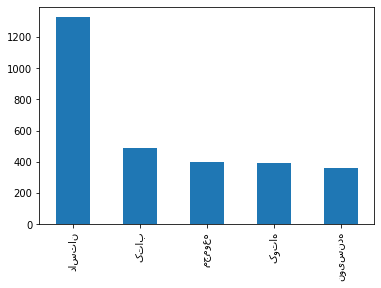

```python
bayes_df['داستان کوتاه'].nlargest(5).plot(kind='bar')
```

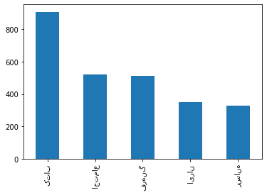

```python
bayes_df['جامعه\u200cشناسی'].nlargest(5).plot(kind='bar')
```

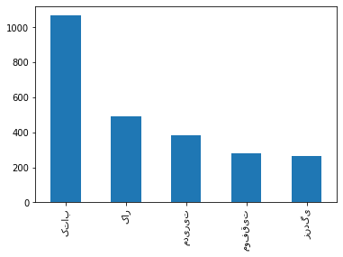

```python
bayes_df['مدیریت و کسب و کار'].nlargest(5).plot(kind='bar')
```

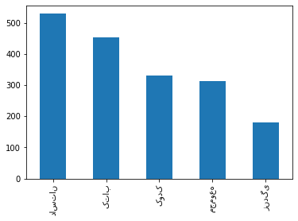

```python
bayes_df['داستان کودک و نوجوانان'].nlargest(5).plot(kind='bar')
```

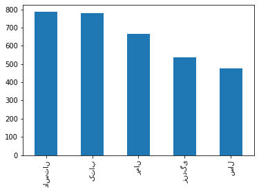

```python
bayes_df['رمان'].nlargest(5).plot(kind='bar')
```

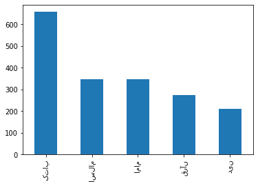

```python
bayes_df['کلیات اسلام'].nlargest(5).plot(kind='bar')
```

```python
EPS = np.nextafter(np.float64(0), np.float64(1)) * 1e100

def bayes_prob(category, words):
    prob = 0
    c_idx = categories.index(category)
    for w in words:
        if w not in vocab:
            prob += np.log(EPS / cat_cnt_df.values[c_idx, 0])
        else:
            w_idx = vocab[w]
            prob += np.log(max(bayes_df.values[w_idx, c_idx], EPS) / cat_cnt_df.values[c_idx, 0])

    return prob

test_df_dup = test_df.copy()
test_df_dup['categories_guessed'] = ''

start_time = time.time()

for r in range(test_rows):
    probs = [-1e10 for i in range(len(categories))]
    sentence = test_df_dup.xs(r)['title'] + ' ' + test_df_dup.xs(r)['description']
    words = break_sent(sentence)

    for i in range(len(categories)):
        probs[i] = bayes_prob(categories[i], words)
    cat_guessed = categories[probs.index(max(probs))]
    test_df_dup.at[r, 'categories_guessed'] = cat_guessed

print(f'execution time: {time.time() - start_time} seconds')
display(test_df_dup)
```

```
execution time: 5.600778102874756 seconds
```

|  | title | description | categories | categories_guessed |
| --- | --- | --- | --- | --- |
| 0 | کآشوب | «کآشوب (بیست و سه روایت از روضه‌هایی که زندگی ... | داستان کوتاه | رمان |
| 1 | داستان‌های برق‌آسا | «داستان‌های برق‌آسا» نام مجموعه داستان‌هایی به... | داستان کوتاه | داستان کوتاه |
| 2 | بحثی درباره مرجعیت و روحانیت | مجموعه مقالات «بحثی درباره مرجعیت و روحانیت» ش... | کلیات اسلام | کلیات اسلام |
| 3 | قلعه‌ی حیوانات | «قلعه‌ی حیوانات» جورج اورول، درباره گروهی از ح... | رمان | رمان |
| 4 | قصه ما مثل شد (۱) | «قصه ما مثل شد» یک مجموعه کتاب ۵ جلدی است که د... | داستان کودک و نوجوانان | داستان کودک و نوجوانان |
| ... | ... | ... | ... | ... |
| 445 | سیره اقتصادی امام علی (ع) | «سیرۀ اقتصادی امام علی (ع)» نوشته سید رضا حسین... | کلیات اسلام | کلیات اسلام |
| 446 | تفنگ پدر بر بام‌های تهران | از روی بام رفته بودیم بر بامی دیگر و رسیده بود... | رمان | رمان |
| 447 | اصالت من | «اصالت من» نوشته داریوش قاسمیان دستجردی (۱۳۳۹)... | جامعه‌شناسی | جامعه‌شناسی |
| 448 | تأمین مالی آموزش و پرورش در ایران | تأمین مالی آموزش و پرورش عمومی فرآیندی است که ... | جامعه‌شناسی | جامعه‌شناسی |
| 449 | جایی که ماه نیست (شوک سقوط) | نیتان فایلر، نویسنده انگلیسی است. \n «جایی که ... | رمان | داستان کوتاه |

450 rows × 4 columns

```python
def report(result_df):
    categories_true = list(result_df['categories'])
    categories_guessed = list(result_df['categories_guessed'])
    cr = classification_report(y_true=categories_true, y_pred=categories_guessed,\
                               target_names=categories, output_dict=True)
    display(pd.DataFrame(data=cr).T)

report(test_df_dup)
```

|  | precision | recall | f1-score | support |
| --- | --- | --- | --- | --- |
| جامعه‌شناسی | 0.653061 | 0.853333 | 0.739884 | 75.000000 |
| کلیات اسلام | 0.492063 | 0.413333 | 0.449275 | 75.000000 |
| داستان کودک و نوجوانان | 0.916667 | 0.586667 | 0.715447 | 75.000000 |
| داستان کوتاه | 0.495868 | 0.800000 | 0.612245 | 75.000000 |
| مدیریت و کسب و کار | 0.932203 | 0.733333 | 0.820896 | 75.000000 |
| رمان | 0.934426 | 0.760000 | 0.838235 | 75.000000 |
| accuracy | 0.691111 | 0.691111 | 0.691111 | 0.691111 |
| macro avg | 0.737381 | 0.691111 | 0.695997 | 450.000000 |
| weighted avg | 0.737381 | 0.691111 | 0.695997 | 450.000000 |

## 7. On the Decision of Metrics

Suppose a model predicts a tiny fraction of true positives in a dataset; consider the following example:

$$y_{true} = [0, 1, 1, 1, 1, 0, 0, 0, 0, 1]$$$$y_{pred} = [0, 1, 0, 0, 0, 0, 0, 0, 0, 0]$$

By definition, we have:

$$\text{Precision} = \frac{\text{True Positives}}{\text{Total Predicted Positives}} = 1$$

Now, consider a situation where our model predicts too many false positives; consider the following example:

$$y_{true} = [0, 1, 1, 1, 1, 0, 0, 0, 0, 1]$$$$y_{pred} = [1, 1, 1, 1, 1, 0, 1, 1, 1, 1]$$

By definition, we have:

$$\text{Recall} = \frac{\text{True Positives}}{\text{Total Actual Positives}} = 1$$

As we see, precision and recall, on their own, are not informative enough on how good our model is.

## 8. F1 to Break the Deal

As demonstrated above, good numbers for Precision or Recall only are not always the best way to evaluate a model; we also know that, if Recall is high because of too many False Positives, Precision drops, and if Precision is high because of too many False Negatives, Recall drops. The F1 metric can help us in understanding how Recall and Precision are standing against each other.

By definition, we have:

$$\text{F1} = 2\times\frac{\text{Precision}\times\text{Recall}}{\text{Precision}+\text{Recall}}$$

If we look more closely, we can see that F1 is actually the harmonic mean of Recall and Precision.

For two values $x, y$, the harmonic mean $HM$ is defined as follows:

$$HM(x, y)=\frac{2}{\frac{1}{x} + \frac{1}{y}} = 2\times\frac{xy}{x+y}$$

With a good amount of effort, one can prove the following inequality:

$$\min(x_1,\dots,x_n)\le \frac{n}{\frac{1}{x_1} + \dots + \frac{1}{x_n}} \le \sqrt[n]{x_1\dots x_n}\dots \le \frac{x_1 + \dots + x_n}{n} \le \max(x_1,\dots,x_n)$$

Therefore, harmonic mean is the closest mean to the minimum value; for example, we have: $HM(0, 100)=0$

With the provided property for harmonic mean, we can get an average of Precision and Recall without ignoring the derrogatory impact of a false value for one on the other.

```python
smooth_df = bayes_df.copy()
smooth_df += 1

cat_smooth_df = smooth_df.sum().to_frame(name='count')

display(cat_smooth_df)
display(smooth_df)
```

|  | count |
| --- | --- |
| جامعه‌شناسی | 74153.0 |
| کلیات اسلام | 61698.0 |
| داستان کودک و نوجوانان | 47425.0 |
| داستان کوتاه | 68603.0 |
| مدیریت و کسب و کار | 64253.0 |
| رمان | 81474.0 |

|  | جامعه‌شناسی | کلیات اسلام | داستان کودک و نوجوانان | داستان کوتاه | مدیریت و کسب و کار | رمان |
| --- | --- | --- | --- | --- | --- | --- |
| یوفو | 1.0 | 1.0 | 1.0 | 2.0 | 1.0 | 1.0 |
| توقیع | 1.0 | 2.0 | 1.0 | 1.0 | 1.0 | 1.0 |
| اسکارلت | 1.0 | 1.0 | 1.0 | 1.0 | 1.0 | 2.0 |
| کمرنگ | 1.0 | 1.0 | 1.0 | 1.0 | 1.0 | 6.0 |
| علاقه | 9.0 | 6.0 | 9.0 | 19.0 | 16.0 | 29.0 |
| ... | ... | ... | ... | ... | ... | ... |
| گلاسیوف | 1.0 | 1.0 | 1.0 | 2.0 | 1.0 | 1.0 |
| جاناکی | 1.0 | 1.0 | 2.0 | 1.0 | 1.0 | 1.0 |
| جدل | 1.0 | 1.0 | 1.0 | 1.0 | 1.0 | 4.0 |
| عصبی | 2.0 | 1.0 | 1.0 | 6.0 | 3.0 | 3.0 |
| توقیف | 1.0 | 1.0 | 1.0 | 2.0 | 1.0 | 3.0 |

26765 rows × 6 columns

```python
def smooth_prob(category, words):
    prob = 0
    c_idx = categories.index(category)
    for w in words:
        if w not in vocab:
            prob += np.log(1 / cat_smooth_df.values[c_idx, 0])
        else:
            w_idx = vocab[w]
            prob += np.log(max(smooth_df.values[w_idx, c_idx], EPS) / cat_smooth_df.values[c_idx, 0])

    return prob

test_smooth_df_dup = test_df.copy()
test_smooth_df_dup['categories_guessed'] = ''

start_time = time.time()

for r in range(test_rows):
    probs = [-1e10 for i in range(len(categories))]
    sentence = test_smooth_df_dup.xs(r)['title'] + ' ' + test_smooth_df_dup.xs(r)['description']
    words = break_sent(sentence)

    for i in range(len(categories)):
        probs[i] = smooth_prob(categories[i], words)
    cat_guessed = categories[probs.index(max(probs))]
    test_smooth_df_dup.at[r, 'categories_guessed'] = cat_guessed

print(f'execution time: {time.time() - start_time} seconds')
display(test_smooth_df_dup)
```

```
execution time: 5.743384599685669 seconds
```

|  | title | description | categories | categories_guessed |
| --- | --- | --- | --- | --- |
| 0 | کآشوب | «کآشوب (بیست و سه روایت از روضه‌هایی که زندگی ... | داستان کوتاه | رمان |
| 1 | داستان‌های برق‌آسا | «داستان‌های برق‌آسا» نام مجموعه داستان‌هایی به... | داستان کوتاه | داستان کوتاه |
| 2 | بحثی درباره مرجعیت و روحانیت | مجموعه مقالات «بحثی درباره مرجعیت و روحانیت» ش... | کلیات اسلام | کلیات اسلام |
| 3 | قلعه‌ی حیوانات | «قلعه‌ی حیوانات» جورج اورول، درباره گروهی از ح... | رمان | جامعه‌شناسی |
| 4 | قصه ما مثل شد (۱) | «قصه ما مثل شد» یک مجموعه کتاب ۵ جلدی است که د... | داستان کودک و نوجوانان | داستان کودک و نوجوانان |
| ... | ... | ... | ... | ... |
| 445 | سیره اقتصادی امام علی (ع) | «سیرۀ اقتصادی امام علی (ع)» نوشته سید رضا حسین... | کلیات اسلام | کلیات اسلام |
| 446 | تفنگ پدر بر بام‌های تهران | از روی بام رفته بودیم بر بامی دیگر و رسیده بود... | رمان | داستان کوتاه |
| 447 | اصالت من | «اصالت من» نوشته داریوش قاسمیان دستجردی (۱۳۳۹)... | جامعه‌شناسی | جامعه‌شناسی |
| 448 | تأمین مالی آموزش و پرورش در ایران | تأمین مالی آموزش و پرورش عمومی فرآیندی است که ... | جامعه‌شناسی | جامعه‌شناسی |
| 449 | جایی که ماه نیست (شوک سقوط) | نیتان فایلر، نویسنده انگلیسی است. \n «جایی که ... | رمان | رمان |

450 rows × 4 columns

```python
report(test_smooth_df_dup)
```

|  | precision | recall | f1-score | support |
| --- | --- | --- | --- | --- |
| جامعه‌شناسی | 0.779070 | 0.893333 | 0.832298 | 75.000000 |
| کلیات اسلام | 0.739726 | 0.720000 | 0.729730 | 75.000000 |
| داستان کودک و نوجوانان | 0.936508 | 0.786667 | 0.855072 | 75.000000 |
| داستان کوتاه | 0.717647 | 0.813333 | 0.762500 | 75.000000 |
| مدیریت و کسب و کار | 0.945205 | 0.920000 | 0.932432 | 75.000000 |
| رمان | 0.900000 | 0.840000 | 0.868966 | 75.000000 |
| accuracy | 0.828889 | 0.828889 | 0.828889 | 0.828889 |
| macro avg | 0.836359 | 0.828889 | 0.830166 | 450.000000 |
| weighted avg | 0.836359 | 0.828889 | 0.830166 | 450.000000 |

## 11.2. Multi-Class F1

So far, we've provided enough information on measuring F1 for a single-class problem; now let's consider we have $n$ classes, namely $C_1,\dots,C_n$ with probabilities of $P(C_1),\dots,P(C_n)$.

Macro F1 just calculates the arithmetic mean of F1 for each class:

$$\text{Macro-F1} = \frac{F_{1,1}+\dots+F_{1,n}}{n}$$

Weighted F1 takes the probabilities of classes in account:

$$\text{Weighted-F1} = P(C_1)F_{1,1}+\dots+P(C_n)F_{1,n}$$

Micro F1 uses a rather different approach; instead of finding Precision and Recall for each class, we find these values over all classes; using this approach, we have:

$$\text{micro-Precision}=\text{micro-Recall}=\text{micro-F1}$$

## 12. When Naive Bayes Makes Mistakes

We first find the samples where our model made a mistake:

```python
wrong_df = test_smooth_df_dup[test_smooth_df_dup['categories'] != test_smooth_df_dup['categories_guessed']]
display(wrong_df)
```

|  | title | description | categories | categories_guessed |
| --- | --- | --- | --- | --- |
| 0 | کآشوب | «کآشوب (بیست و سه روایت از روضه‌هایی که زندگی ... | داستان کوتاه | رمان |
| 3 | قلعه‌ی حیوانات | «قلعه‌ی حیوانات» جورج اورول، درباره گروهی از ح... | رمان | جامعه‌شناسی |
| 5 | اسلام و چالش اقتصادی | «اسلام و چالش اقتصادی» نوشته محمد عمر چپرا (-۱... | کلیات اسلام | جامعه‌شناسی |
| 12 | زندانی قلعه‌ی قهقهه | رمان تاریخی «زندانی قلعه قهقهه» روایت‌گر سرگذش... | داستان کوتاه | رمان |
| 20 | فاطمه علی است | «فاطمه علی است» نوشته علی قهرمانی کتابی درباره... | کلیات اسلام | رمان |
| ... | ... | ... | ... | ... |
| 434 | وقتی همه خوابند | «وقتی همه خوابند» کتابی است به قلم بنفشه چاپار... | رمان | داستان کوتاه |
| 435 | فردریک شوپن | «فردریک شوپن» سرگذشت داستانی موسیقیدان مشهور ل... | داستان کودک و نوجوانان | رمان |
| 437 | تارهای جادویی فرانکی پرستو | «تارهای جادویی فرانکی پرستو» رمانی از میچ آلبو... | رمان | داستان کوتاه |
| 438 | مرد بدلی | کتاب «مرد بدلی» از مجموعه کتاب‌های راه طی شده ... | جامعه‌شناسی | رمان |
| 446 | تفنگ پدر بر بام‌های تهران | از روی بام رفته بودیم بر بامی دیگر و رسیده بود... | رمان | داستان کوتاه |

77 rows × 4 columns

For an easy instance, consider the first row: we know a novel can be easily mistaken with a short story, not knowing the actual length of the text. Moreover, as extensive as our training data is, it's still limited and we need more diverse data to be fed to our model in order to get a better performance.